# Estatística Aplicada - Conclusão da Disciplina

Vulnerabilidade Social e Segurança Pública

Anderson Cavalcante Silva Aureo Igor Wanderley Ramos Carlos Mauricio Aouad Campos Renan Alcântara Sant’Ana

20 de janeiro de 2021

# 1 Introdução

A percepção cotidiana da violência e criminalidade nos assusta e nos deixa em permanente estado de alerta, as notícias divulgadas diariamente pela grande mídia somente reforçam essa sensação. O [*Atlas da Violência*](https://www.ipea.gov.br/atlasviolencia/download/19/atlas-da-violencia-2019), publicado em 2019, desnuda os índices de ocorrências policiais em todo o Brasil, e especialmente no Estado da Bahia expôe nossa precária situação, com a preocupante situação de possuirmos 4 das 10 cidades mais violentas do país.

Essa percepção sobre a violência aliada aos dados do Atlas nos deixam algumas perguntas no ar: Qual parte da Bahia é mais violenta ? A Capital e sua Região Metropolitana, ou o Interior do Estado ? Em qual região da Bahia esses índices são mais alarmantes ?

Visando a conclusão da disciplina *Estatística Aplicada a R*, do curso de **Big Data & Analytics** do SENAI/CIMATEC, construimos esse relatório para avaliar o grau de correlação entre as ocorrências de Segurança Pública no Estado da Bahia e os Índice de Vulnerabilidade Social (IVS) e de Desenvolvimento Humano dos Municípios (IDHM).

**A análise desses dados diversos nos remetem a algumas questões a serem respondidas:**  
1 - Qual o grau de correlação entre os índices de criminalidade e os IDHM e IVS ?  
2 - As ocorrências policiais guardam alguma correlação com as condições de moradia da população ?  
3 - A Taxa de pessoas pobres tem impacto sobre a violência ?  
4 - A Renda Per Capta impacta no IDHM ?  
5 - De maneira bem simplificada a Teoria das Janelas Quebradas[^1], de James Q. Wilson e George Kelling, traz um conceito de causalidade entre a desordem e a pratica de delitos. Com esse conceito de que **a desordem gera desordem**, em comparação com os dados coletados sobre a infraestrutura urbana, é possível verificar a assertividade dessa teoria em nossa realidade ?

# 2 Sobre nossa Base de Dados

A construção da Base de Dados foi feita com as seguintes informações:  
IBGE: [*Poligonais dos Municípios da Bahia*](https://www.ibge.gov.br/cidades-e-estados/ba.html);  
IBGE: [*Atlas do Desenvolvimento Humano dos Municípios*](https://www.br.undp.org/content/brazil/pt/home/idh0/atlas-do-desenvolvimento-humano/atlas-dos-municipios.html);  
IPEA: [*Atlas da Vulnerabilidade Social*](https://dados.gov.br/dataset/ivs);  
Informações oriundas da Secretaria da Segurança Pública da Bahia (SSP-BA) de Janeiro a Dezembro de 2018[^2].

## 2.1 Municípios

Apesar de conter outras variáveis, a tabela de Municípios foi apresentada somente com as informações referentes aos seus nomes, siglas e códigos do ente federativo.

| Municipio | COD_UF | UF |
| --- | --- | --- |
| Érico Cardoso | 29 | BA |
| Água Fria | 29 | BA |
| Xique-Xique | 29 | BA |
| Wenceslau Guimarães | 29 | BA |
| Wanderley | 29 | BA |

## 2.2 IDHM

A base de dados IDHM foi adicionada ao projeto visando correlacionar as informações sobre os índices de Desenvolvimento Humanos (IDHM) e Proporção de Extremamente Pobres (PIND) com variáveis ligadas a infraestrutura básica.

Antes de continuar é necessário fazer uma observação quanto ao IDHM. O Índice de Desenvolvimento Humano por Município (IDH-M ou IDHM) é uma variação do Índice de Desenvolvimento Humano (IDH) criado pelo Programa das Nações Unidas para o Desenvolvimento (PNUD) em 1993, possuindo 4 divisões:

- **IDH baixo:** reúne todos os países que apresentam IDH abaixo de 0,500;
- **IDH médio:** países com IDH entre 0,500 e 0,799;
- **IDH alto:** países com desenvolvimento humano entre 0,800 e 0,899;
- **IDH muito alto:** países cujo índice encontra-se igual ou acima de 0,900.

| Municipio | Região | IDHM | PIND | HOMEM | MULHER | T_BANAGUA | T_LIXO | T_LUZ |
| --- | --- | --- | --- | --- | --- | --- | --- | --- |
| Salvador | Metropolitana de Salvador | 0.759 | 3.97 | 1248897 | 1426759 | 95.09 | 96.55 | 99.85 |
| Lauro De Freitas | Metropolitana de Salvador | 0.754 | 3.48 | 79276 | 84173 | 94.17 | 99.02 | 99.75 |
| Barreiras | Extremo Oeste | 0.721 | 5.52 | 67913 | 69514 | 90.73 | 97.30 | 99.36 |
| Luís Eduardo Magalhães | Extremo Oeste | 0.716 | 2.92 | 31056 | 29049 | 93.99 | 100.00 | 99.41 |
| Feira De Santana | Centro-Norte | 0.712 | 5.38 | 263999 | 292643 | 86.61 | 97.43 | 99.77 |

## 2.3 IVS

Para contextualizar as mazelas existentes na nossa sociedade, foi trazida a tabela de Índices de Vulnerabilidade Social (IVS). Informações ligadas a infraestrutura urbana, renda per capita, analfabetismo, entre outros, são importantes para verificação da Teoria da Janela Quebrada.

| Municipio | IVS | IVS_INFRA | IVS_CAP_HUM | IVS_RENDA | R_P_CAPITA | POPULACAO | T_ANALF | I_GINI |
| --- | --- | --- | --- | --- | --- | --- | --- | --- |
| Lamarão | 0.648 | 0.546 | 0.646 | 0.754 | 180.82 | 9560 | 35.38 | 0.50 |
| Andaraí | 0.636 | 0.534 | 0.596 | 0.778 | 230.36 | 13960 | 29.16 | 0.59 |
| Boa Vista Do Tupim | 0.633 | 0.604 | 0.598 | 0.698 | 195.71 | 17991 | 33.52 | 0.56 |
| Itapicuru | 0.615 | 0.399 | 0.704 | 0.742 | 185.70 | 32261 | 41.92 | 0.54 |
| Nova Itarana | 0.604 | 0.391 | 0.694 | 0.726 | 188.86 | 7435 | 33.73 | 0.55 |

## 2.4 SSP-BA

A tabela da SSP possui informações relacionadas aos tipos e quantitativos de ocorrências policiais no nosso Estado.

Alguns ajustes foram necessários para impplementação desse *dataset*: Algumas váriaveis apresentadas são resultados de somas entre outras variárias, a exemplo de CVLI (Homicídio Doloso + Lesão Corporal com Resultado Morte + LATROCÍNIO e TOT_VEIC (Roubo a Coletivos + Roubo de Veículos + Furto de Veículos).

| MUNICÍPIOS | CVLI | HOMI_TEN | ESTUPRO | TOT_VEIC | UP_DROGAS |
| --- | --- | --- | --- | --- | --- |
| Salvador | 1149 | 323 | 352 | 8820 | 1511 |
| Feira De Santana | 369 | 139 | 131 | 612 | 138 |
| Camaçari | 180 | 65 | 73 | 980 | 145 |
| Vitória Da Conquista | 172 | 127 | 118 | 373 | 157 |
| Itabuna | 128 | 92 | 49 | 559 | 82 |

# 3 Analisando dados de algumas variáveis

## 3.1 População

Para ínicio das análises listamos o dataset por **população**. O resultado trouxe a confirmação sobre a expectativa de que as cidades mais populosas seriam as com maiores índices de crimininalidade. É possível verificar rapidamente que a cidade com maior número de mortes é **Salvador**, totalizando **1149** Crimes Violentes Letais e Intencionais (CVLI)[^3].

| Municipio | População | IDHM | IVS | CVLI | Estupros | Soma de Veiculos | Uso/Porte Entorpecentes |
| --- | --- | --- | --- | --- | --- | --- | --- |
| Salvador | 2675656 | 0.759 | 0.350 | 1149 | 352 | 8820 | 1511 |
| Feira De Santana | 556642 | 0.712 | 0.336 | 369 | 131 | 612 | 138 |
| Vitória Da Conquista | 306866 | 0.678 | 0.328 | 172 | 118 | 373 | 157 |
| Camaçari | 242970 | 0.694 | 0.354 | 180 | 73 | 980 | 145 |
| Itabuna | 204667 | 0.712 | 0.310 | 128 | 49 | 559 | 82 |

```
##    Min. 1st Qu.  Median    Mean 3rd Qu.    Max.
##    2612   11154   16713   33614   26591 2675656
```

```
## [1] 136041.9
```

Construimos uma tabela de frequência para verificar a distribuição em cidades de pequeno, médio e grande porte.

|  | Freq | Prop |
| --- | --- | --- |
| Grande Porte | 16 | 3.84 |
| Medio Porte | 27 | 6.47 |
| Pequeno Porte | 374 | 89.69 |

Agrupando as cidades com menos de 50.000 habitantes, entre 50.000 e 100.000 e maiores que 100.000 habitantes, nota-se que 89.69% são consideradas de Pequeno porte, 6.47% de Médio porte e somente 3.84% de Grande porte.

## 3.2 Índice de Desenvolvimento Humano por Município

Listando-se os 05 municípios com maior Índice de Desenvolvimento Humano por Município percebe-se uma possível relação com os números de ocorrências de segurança pública.

| Municipio | Região | IDHM | Taxa de Crimes | Renda Per Capita | Prop Extr Pobres | % Agua Encanada | % Coleta Lixo | % Luz Elétrica |
| --- | --- | --- | --- | --- | --- | --- | --- | --- |
| Salvador | Metropolitana de Salvador | 0.759 | 454.2811 | 973.00 | 3.97 | 95.09 | 96.55 | 99.85 |
| Lauro De Freitas | Metropolitana de Salvador | 0.754 | 567.7612 | 1031.78 | 3.48 | 94.17 | 99.02 | 99.75 |
| Barreiras | Extremo Oeste | 0.721 | 266.3232 | 602.82 | 5.52 | 90.73 | 97.30 | 99.36 |
| Luís Eduardo Magalhães | Extremo Oeste | 0.716 | 542.3842 | 871.12 | 2.92 | 93.99 | 100.00 | 99.41 |
| Feira De Santana | Centro-Norte | 0.712 | 249.5320 | 662.24 | 5.38 | 86.61 | 97.43 | 99.77 |

Os dados listados do 5 municipios com **menor** Índice de Desenvolvimento Humano por Município ratificam as impressões percebidas anteriormente.

| Municipio | Região | IDHM | Taxa de Crimes | Renda Per Capita | Prop Extr Pobres | % Agua Encanada | % Coleta Lixo | % Luz Elétrica |
| --- | --- | --- | --- | --- | --- | --- | --- | --- |
| Itapicuru | Nordeste | 0.486 | 213.88054 | 185.70 | 31.44 | 55.44 | 87.16 | 92.77 |
| Monte Santo | Nordeste | 0.506 | 78.33696 | 197.43 | 35.11 | 22.10 | 95.85 | 91.18 |
| Pilão Arcado | Vale São-Franciscano | 0.506 | 112.59890 | 195.98 | 40.90 | 36.85 | 86.98 | 69.15 |
| Ibiquera | Centro-Norte | 0.511 | 20.55076 | 199.55 | 38.36 | 50.55 | 96.93 | 78.39 |
| Ribeira Do Amparo | Nordeste | 0.512 | 133.09050 | 183.12 | 33.96 | 56.02 | 95.68 | 92.96 |

Com base nas informações do PNUD, fizemos alguns testes para verificarmos a normalidade dos dados de IDHM, comparando-os com o **IDH Alto**.

```
##
##  One Sample t-test
##
## data:  df$idhm
## t = -102.03, df = 416, p-value < 2.2e-16
## alternative hypothesis: true mean is less than 0.8
## 95 percent confidence interval:
##       -Inf 0.5972341
## sample estimates:
## mean of x
## 0.5939041
```

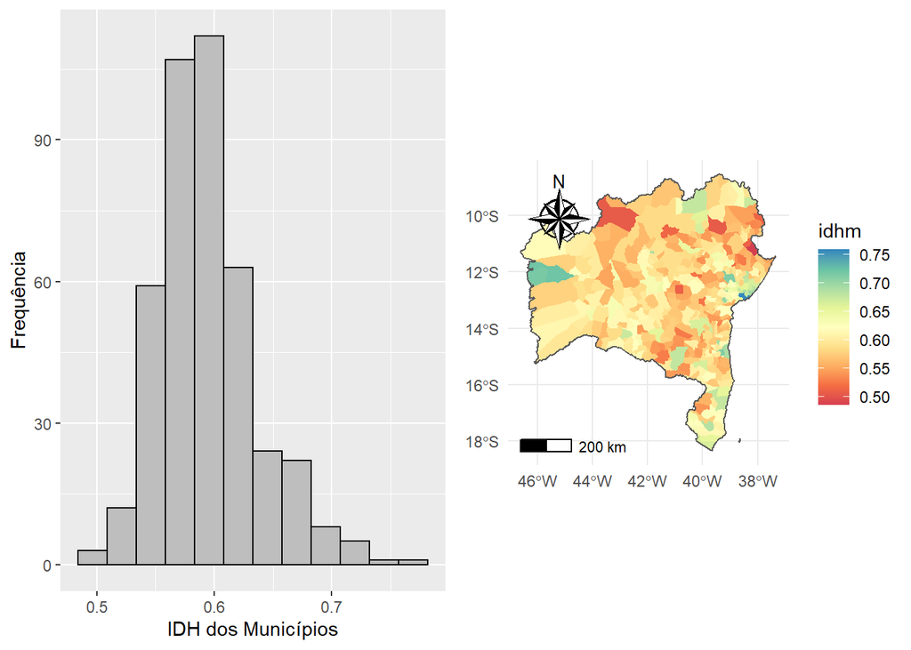

## 3.3 IVS Médio

Listando-se os 05 municípios com maior Índice de Vulnerabilidade Social Médio, percebe-se um reflexo imediato no número de ocorrências de segurança pública.

| Municipíos | Região | População | Porte da Cidade | IVS Médio | Ocorrencias por População | % Ocorrencias por População |
| --- | --- | --- | --- | --- | --- | --- |
| Lamarão | Nordeste | 9560 | Pequeno Porte | 0.648 | 0.0008 | 0.0837 |
| Andaraí | Centro-Sul | 13960 | Pequeno Porte | 0.636 | 0.0011 | 0.1074 |
| Boa Vista Do Tupim | Centro-Norte | 17991 | Pequeno Porte | 0.633 | 0.0004 | 0.0445 |
| Itapicuru | Nordeste | 32261 | Pequeno Porte | 0.615 | 0.0021 | 0.2139 |
| Nova Itarana | Centro-Sul | 7435 | Pequeno Porte | 0.604 | 0.0008 | 0.0807 |

Os dados listados do 5 municipios com **menor** Índice de Vulnerabilidade Social Médio ratificam as impressões percebidas anteriormente.

| Municipíos | Região | População | Porte da Cidade | IVS Médio | Ocorrencias por População | % Ocorrencias por População |
| --- | --- | --- | --- | --- | --- | --- |
| Luís Eduardo Magalhães | Extremo Oeste | 60105 | Medio Porte | 0.267 | 0.0054 | 0.5424 |
| Barreiras | Extremo Oeste | 137427 | Grande Porte | 0.273 | 0.0027 | 0.2663 |
| Itapetinga | Centro-Sul | 68273 | Medio Porte | 0.283 | 0.0039 | 0.3852 |
| Santo Antônio De Jesus | Metropolitana de Salvador | 90985 | Medio Porte | 0.294 | 0.0041 | 0.4089 |
| Madre De Deus | Metropolitana de Salvador | 17376 | Pequeno Porte | 0.295 | 0.0047 | 0.4719 |

O desvio padrão da variável Índice de Vulnerabilidade Social Médio é igual a 0.0660049. Indicando que, em média, as observações diferem em 0.0660049 da média da variável. Observamos uma média de 0.4541415, bem próxima da mediana 0.458. A proximidade entre as duas medidas de centralidade indicam uma possível simetria nos dados.

```
##    Min. 1st Qu.  Median    Mean 3rd Qu.    Max.
##  0.2670  0.4090  0.4580  0.4541  0.5000  0.6480
```

```
## [1] 0.06600486
```

Os gráficos gerados confirmam visualmente a simetria indicada pelas medidas de dispersão para a variável Índice de Vulnerabilidade Social Médio, indicando que a variável aparenta seguir uma distribuição Normal.

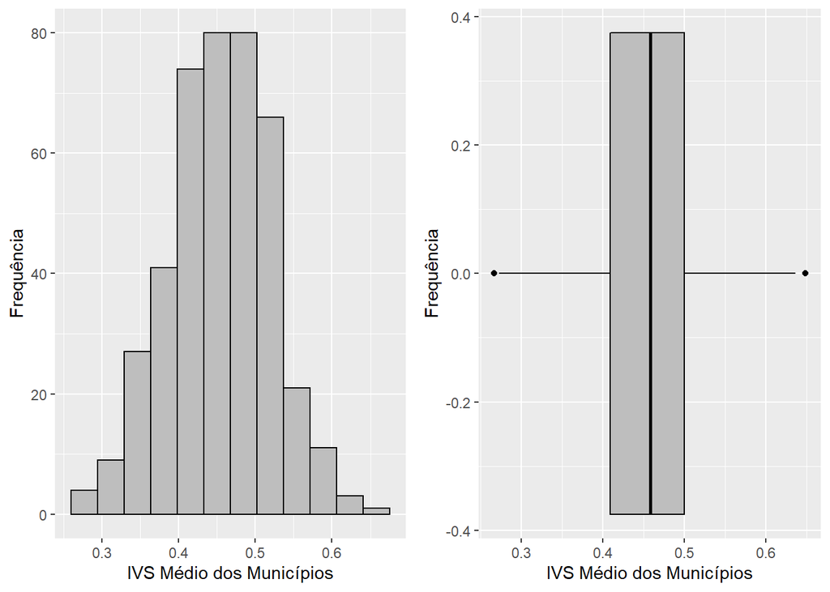

Tabela de Ocorrencias Policiais e Taxas de Crimes, agrupadas por Região

| Região | População | Tot Ocorr Policiais | Taxa de Crimes | Coordenadas |
| --- | --- | --- | --- | --- |
| Sul | 2011740 | 5341 | 13736.289 | MULTIPOLYGON (((-39.86409 -… |
| Centro-Sul | 2478787 | 3826 | 12041.978 | POLYGON ((-39.77288 -15.566… |
| Centro-Norte | 2226300 | 4018 | 11101.030 | POLYGON ((-39.47441 -12.847… |
| Nordeste | 1545922 | 3316 | 10681.453 | POLYGON ((-39.07651 -11.828… |
| Metropolitana de Salvador | 4210499 | 18011 | 10133.261 | POLYGON ((-39.1931 -13.0714… |
| Vale São-Franciscano | 964405 | 1740 | 3351.280 | MULTIPOLYGON (((-43.86481 -… |
| Extremo Oeste | 579253 | 1067 | 2734.524 | POLYGON ((-44.4678 -14.0324… |

## 3.4 IVS Infraestrutura Urbana

| Municipios | IVS Infra Urbana | % Agua Encanada | % Coleta Lixo | % Luz Elétrica | CVLI | Estupros | Soma de Veiculos | Uso/Porte Entorpecentes |
| --- | --- | --- | --- | --- | --- | --- | --- | --- |
| Macururé | 0.618 | 40.59 | 36.13 | 86.12 | 3 | 0 | 0 | 0 |
| Boa Vista Do Tupim | 0.604 | 32.75 | 99.85 | 83.48 | 3 | 1 | 2 | 0 |
| Itaeté | 0.576 | 59.21 | 86.36 | 93.54 | 4 | 1 | 0 | 0 |
| Pedro Alexandre | 0.574 | 20.61 | 81.03 | 69.65 | 6 | 5 | 4 | 1 |
| Lamarão | 0.546 | 29.60 | 70.25 | 95.00 | 3 | 0 | 2 | 1 |

Os dados listados do 5 municipios com **menor** Índice de Vulnerabilidade Social na dimensão Infraestrutura Urbana ratificam as impressões percebidas anteriormente.

| Municipios | IVS Infra Urbana | % Agua Encanada | % Coleta Lixo | % Luz Elétrica | CVLI | Estupros | Soma de Veiculos | Uso/Porte Entorpecentes |
| --- | --- | --- | --- | --- | --- | --- | --- | --- |
| Itapetinga | 0.064 | 95.63 | 98.63 | 99.17 | 13 | 25 | 28 | 161 |
| Rodelas | 0.077 | 89.47 | 91.60 | 98.80 | 4 | 1 | 4 | 2 |
| Paramirim | 0.080 | 87.94 | 95.50 | 93.42 | 0 | 5 | 10 | 8 |
| Ibititá | 0.098 | 79.59 | 94.21 | 98.74 | 1 | 3 | 7 | 1 |
| Coaraci | 0.100 | 82.34 | 99.04 | 96.76 | 10 | 7 | 1 | 18 |

O desvio padrão da variável IVS Infraestrutura Urbana é igual a 0.1016511. Indicando que, em média, as observações diferem em 0.1016511 da média da variável. Observamos uma média de 0.2760887, bem próxima da mediana 0.269. A proximidade entre as duas medidas de centralidade indicam uma possível simetria nos dados.

```
##    Min. 1st Qu.  Median    Mean 3rd Qu.    Max.
##  0.0640  0.1990  0.2690  0.2761  0.3410  0.6180
```

```
## [1] 0.1016511
```

Os gráficos gerados confirmam visualmente a simetria indicada pelas medidas de dispersão para a variável IVS Infraestrutura Urbana, indicando que a variável aparenta seguir uma distribuição Normal.

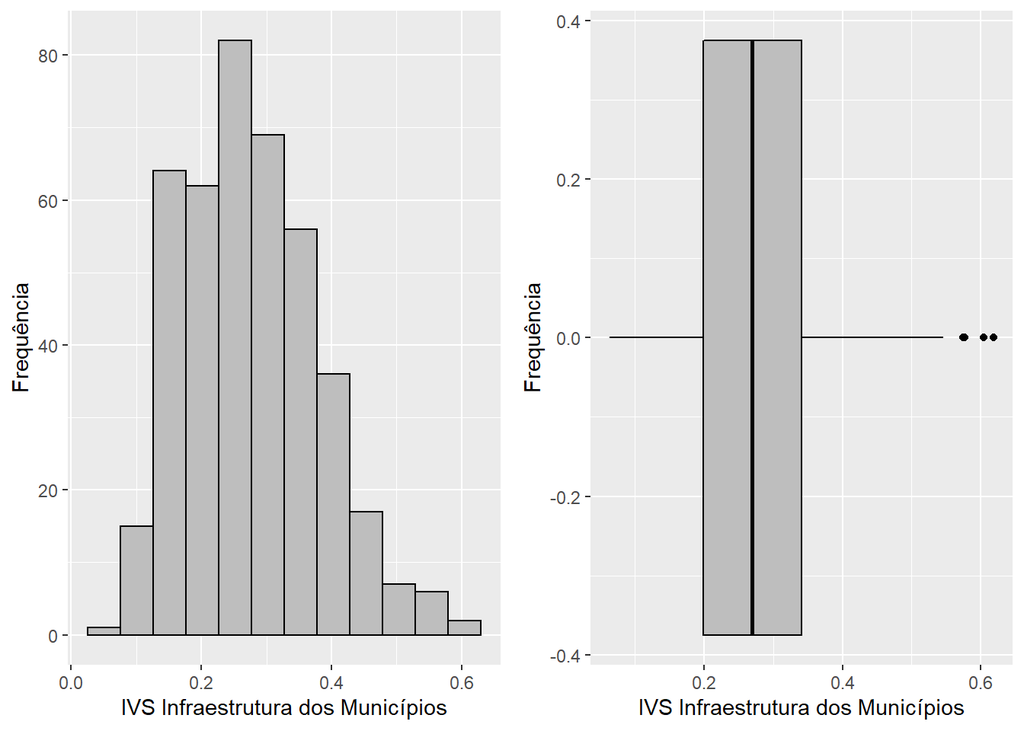

## 3.5 IVS Renda e Trabalho

Os dados dos 05 municipios com maior Índice de Vulnerabilidade Social na dimensão Renda e Trabalho seguem o mesmo padrão do IVS Infraestrutura Urbana no número de ocorrências de segurança pública.

| Municipíos | IVS Renda Trabalho | Renda Per Capita | CVLI | Estupros | Soma de Veículos | Uso/Porte Entorpecentes |
| --- | --- | --- | --- | --- | --- | --- |
| Dário Meira | 0.808 | 206.16 | 3 | 6 | 1 | 5 |
| Andaraí | 0.778 | 230.36 | 1 | 1 | 4 | 7 |
| Lamarão | 0.754 | 180.82 | 3 | 0 | 2 | 1 |
| Ipecaetá | 0.746 | 186.54 | 1 | 2 | 18 | 0 |
| Oliveira Dos Brejinhos | 0.743 | 220.72 | 5 | 5 | 11 | 1 |

Os dados dos 05 municipios com **menor** Índice de Vulnerabilidade Social na dimensão Renda e Trabalho confirmam com muito mais ênfase que as impressões apresentadas pelo IVS Infraestrutura Urbana.

| Municípios | IVS Renda Trabalho | Renda Per Capita | CVLI | Estupros | Soma de Veículos | Uso/Porte Entorpecentes |
| --- | --- | --- | --- | --- | --- | --- |
| Luís Eduardo Magalhães | 0.259 | 871.12 | 55 | 34 | 169 | 58 |
| Lauro De Freitas | 0.288 | 1031.78 | 95 | 44 | 689 | 65 |
| Barreiras | 0.317 | 602.82 | 46 | 50 | 188 | 52 |
| Salvador | 0.324 | 973.00 | 1149 | 352 | 8820 | 1511 |
| Itapetinga | 0.364 | 506.76 | 13 | 25 | 28 | 161 |

O desvio padrão da variável IVS Renda e Trabalho é igual a 0.081922. Indicando que, em média, as observações diferem em 0.081922 da média da variável. Observamos uma média de 0.5600983, bem próxima da mediana 0.564. A proximidade entre as duas medidas de centralidade indicam uma possível simetria nos dados.

```
##    Min. 1st Qu.  Median    Mean 3rd Qu.    Max.
##  0.2590  0.5120  0.5640  0.5601  0.6130  0.8080
```

```
## [1] 0.08192203
```

Os gráficos gerados confirmam visualmente a simetria indicada pelas medidas de dispersão para a variável IVS Renda e Trabalho, indicando que a variável aparenta seguir uma distribuição Normal.

[figure not shown]

## 3.6 Proporção de Extremamente Pobres

O Atlas do Desenvolvimento Humano dos Municípios nos apresenta essa variável da Proporção dos indivíduos com renda domiciliar per capita igual ou inferior a R$ 70,00 mensais, em reais de agosto de 2010.

Os dados dos 05 municipios com menor Proporção de Extremamente Pobres refletem uma possível força de atração para a criminalidade, aparentando uma relação linear negativa, ou inversamente proposcional.

| Municipíos | Prop Extremamente Pobres | Taxa de Crimes | CVLI | Estupros | Soma de Veículos | Uso/Porte Entorpecentes |
| --- | --- | --- | --- | --- | --- | --- |
| Itapetinga | 2.66 | 385.2182 | 13 | 25 | 28 | 161 |
| Luís Eduardo Magalhães | 2.92 | 542.3842 | 55 | 34 | 169 | 58 |
| Lauro De Freitas | 3.48 | 567.7612 | 95 | 44 | 689 | 65 |
| Salvador | 3.97 | 454.2811 | 1149 | 352 | 8820 | 1511 |
| Eunápolis | 5.21 | 373.2684 | 51 | 41 | 208 | 27 |

Os dados dos 05 municipios com **maior** Proporção de Extremamente Pobres confirmam as impressões apresentadas no tabela anterior.

| Municipíos | Prop Extremamente Pobres | Taxa de Crimes | CVLI | Estupros | Soma de Veículos | Uso/Porte Entorpecentes |
| --- | --- | --- | --- | --- | --- | --- |
| Sítio Do Mato | 47.77 | 141.07884 | 5 | 0 | 12 | 0 |
| Barra | 41.55 | 52.71161 | 6 | 1 | 0 | 3 |
| Pilão Arcado | 40.90 | 112.59890 | 4 | 6 | 10 | 4 |
| Campo Alegre De Lourdes | 40.51 | 35.59986 | 1 | 6 | 2 | 1 |
| Ibiquera | 38.36 | 20.55076 | 0 | 0 | 1 | 0 |

O desvio padrão da variável Proporção de Extremamente Pobres é igual a 8.1889686. Indicando que, em média, as observações diferem em 8.1889686 da média da variável. Observamos uma média de 20.0423981, bem próxima da mediana 19.44. A proximidade entre as duas medidas de centralidade indicam uma possível simetria nos dados.

```
##    Min. 1st Qu.  Median    Mean 3rd Qu.    Max.
##    2.66   13.55   19.44   20.04   25.61   47.77
```

```
## [1] 8.188969
```

Os gráficos gerados confirmam visualmente a simetria indicada pelas medidas de dispersão para a variável Proporção de Extremamente Pobres, indicando que a variável aparenta seguir uma distribuição Normal.

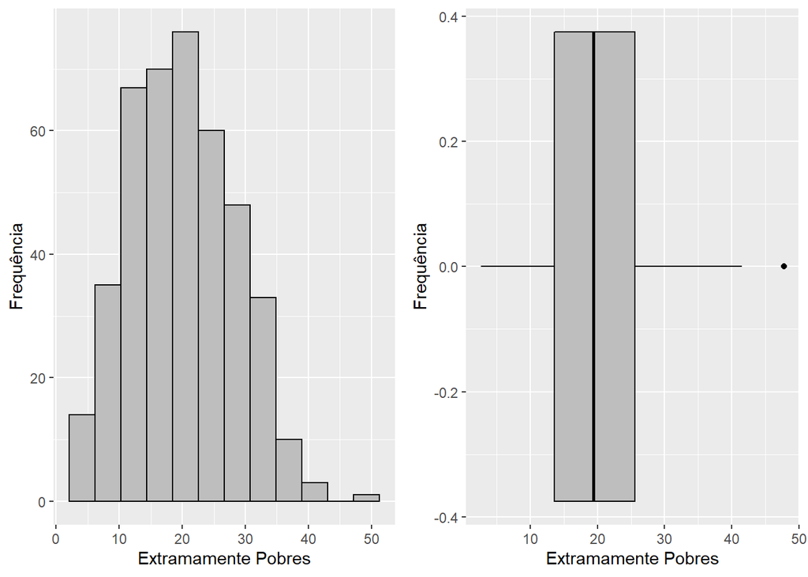

## 3.7 Taxa de crimes (Totais)

Dos 10 municipios com maior Taxa de Crimes Totais, 50% estão localizados na Grande Salvador e o resto distribuidos entre Nordeste e Extremo Oeste, além disso precebe-se que eles estão presentes em todos os portes de cidades, vistas pelo ponto de vista populacional, demonstrando que o flagelo da criminalidade não discrimina porte nem região.

| Municipíos | Região | Porte da Cidade | Taxa de Crimes | CVLI | Estupros | Soma de Veículos | Uso/Porte Entorpecentes |
| --- | --- | --- | --- | --- | --- | --- | --- |
| Camaçari | Metropolitana de Salvador | Grande Porte | 593.9005 | 180 | 73 | 980 | 145 |
| Dias D’ávila | Metropolitana de Salvador | Medio Porte | 576.4600 | 56 | 25 | 134 | 150 |
| Entre Rios | Nordeste | Pequeno Porte | 571.8299 | 39 | 14 | 122 | 32 |
| Lauro De Freitas | Metropolitana de Salvador | Grande Porte | 567.7612 | 95 | 44 | 689 | 65 |
| Inhambupe | Nordeste | Pequeno Porte | 561.8906 | 21 | 18 | 76 | 57 |
| Luís Eduardo Magalhães | Extremo Oeste | Medio Porte | 542.3842 | 55 | 34 | 169 | 58 |
| Araças | Nordeste | Pequeno Porte | 501.6867 | 5 | 6 | 37 | 5 |
| Alagoinhas | Nordeste | Grande Porte | 479.0453 | 98 | 50 | 437 | 29 |
| Madre De Deus | Metropolitana de Salvador | Pequeno Porte | 471.9153 | 5 | 9 | 5 | 50 |
| Simões Filho | Metropolitana de Salvador | Grande Porte | 459.9863 | 104 | 10 | 399 | 16 |

O desvio padrão da variável Taxa de Crimes é igual a 114.2860146. Indicando que, em média, as observações diferem em 114.2860146 da média da variável. Observamos uma média de 152.9492011, razoavelmente próxima da mediana 122.9760197. A proximidade entre as duas medidas de centralidade indicam uma fraca simetria nos dados.

```
##    Min. 1st Qu.  Median    Mean 3rd Qu.    Max.
##    0.00   74.93  122.98  152.95  200.19  593.90
```

```
## [1] 114.286
```

Percebemos também uma grande incidência de valores destoantes (outliers) no gráfico boxplot, que requerem atenção para não distorcerem as análises a serem realizadas.

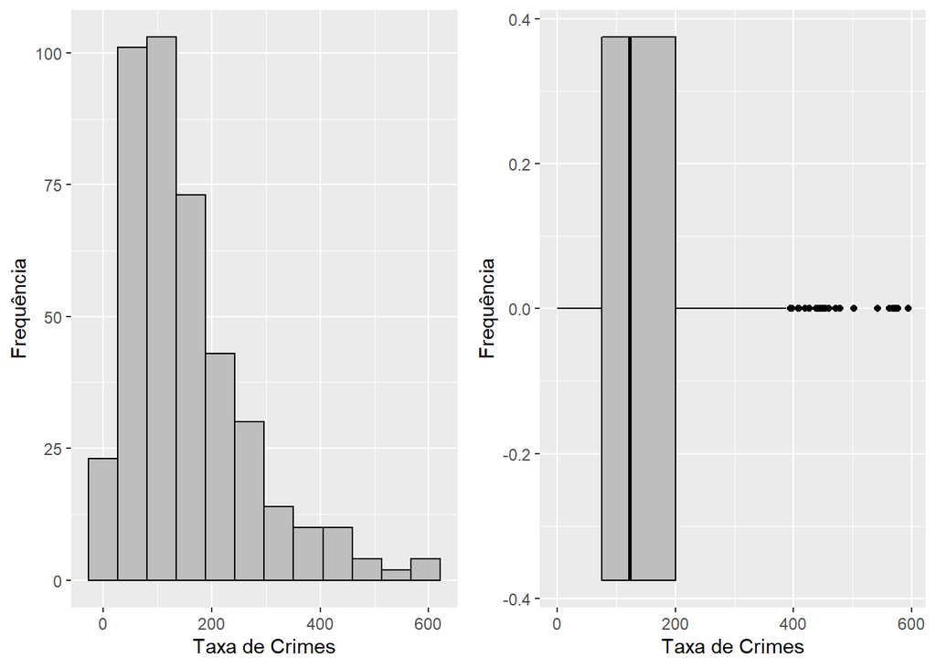

Testamos algumas transformações para confirmar a tendencia observada da distribuição da variável seguir uma distribuição Normal, e auxiliar na confirmação da confiabilidade das inferências, e todas as transformações confirmaram a tendência para uma distribuição Normal.

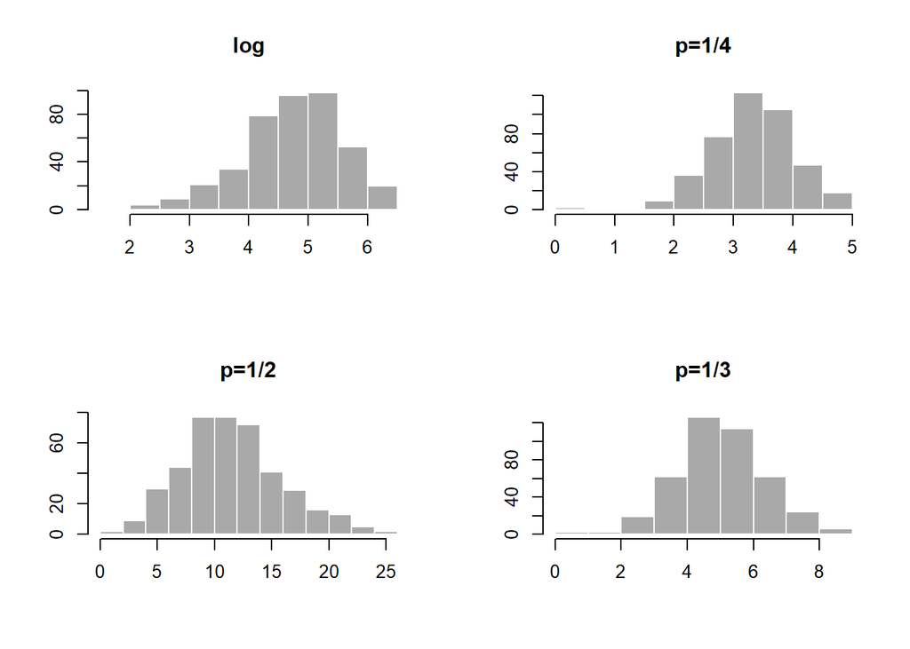

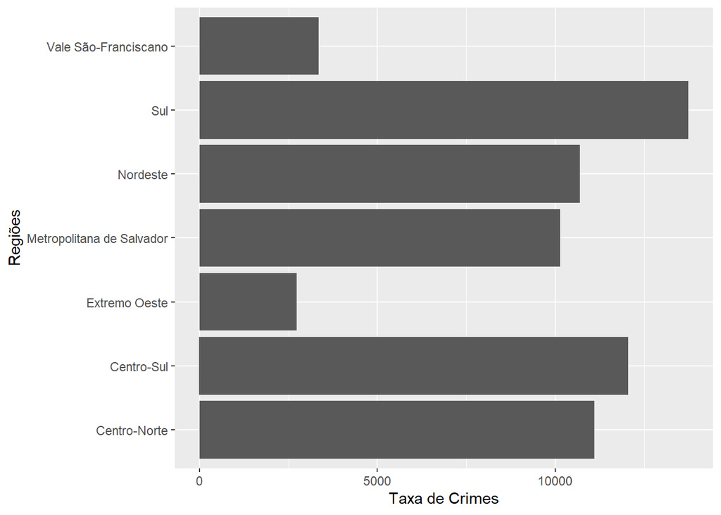

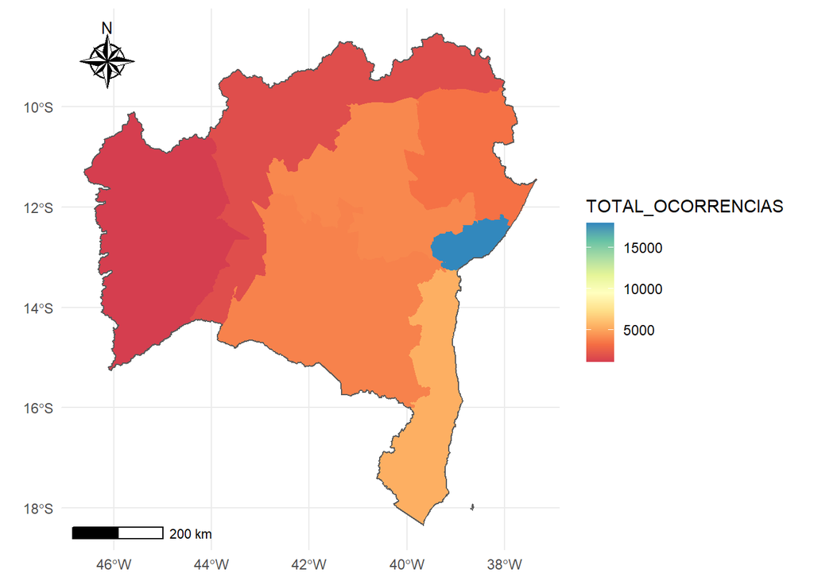

## 3.8 Total de Ocorrencias Policiais por População

| Municipíos | Região | População | Porte da Cidade | Ocorrencias por População | % Ocorrencias por População | Total Ocorrencias por Porte Cidade | IDHM Médio | IVS Médio | GINI Médio |
| --- | --- | --- | --- | --- | --- | --- | --- | --- | --- |
| Camaçari | Metropolitana de Salvador | 242970 | Grande Porte | 0.0059 | 0.5939 | 1443 | 0.694 | 0.354 | 0.53 |
| Dias D’ávila | Metropolitana de Salvador | 66440 | Medio Porte | 0.0058 | 0.5765 | 383 | 0.676 | 0.362 | 0.50 |
| Entre Rios | Nordeste | 39872 | Pequeno Porte | 0.0057 | 0.5718 | 228 | 0.615 | 0.464 | 0.60 |
| Lauro De Freitas | Metropolitana de Salvador | 163449 | Grande Porte | 0.0057 | 0.5678 | 928 | 0.754 | 0.303 | 0.63 |
| Inhambupe | Nordeste | 36306 | Pequeno Porte | 0.0056 | 0.5619 | 204 | 0.565 | 0.484 | 0.53 |

O desvio padrão da variável Total de Ocorrencias Policiais por População é igual a 0.0011429. Indicando que, em média, as observações diferem em 0.0011429 da média da variável. Observamos uma média de 0.0015295, próxima da mediana 0.0012298. A proximidade entre as duas medidas de centralidade indicam uma provável simetria nos dados.

```
##      Min.   1st Qu.    Median      Mean   3rd Qu.      Max.
## 0.0000000 0.0007493 0.0012298 0.0015295 0.0020019 0.0059390
```

```
## [1] 0.00114286
```

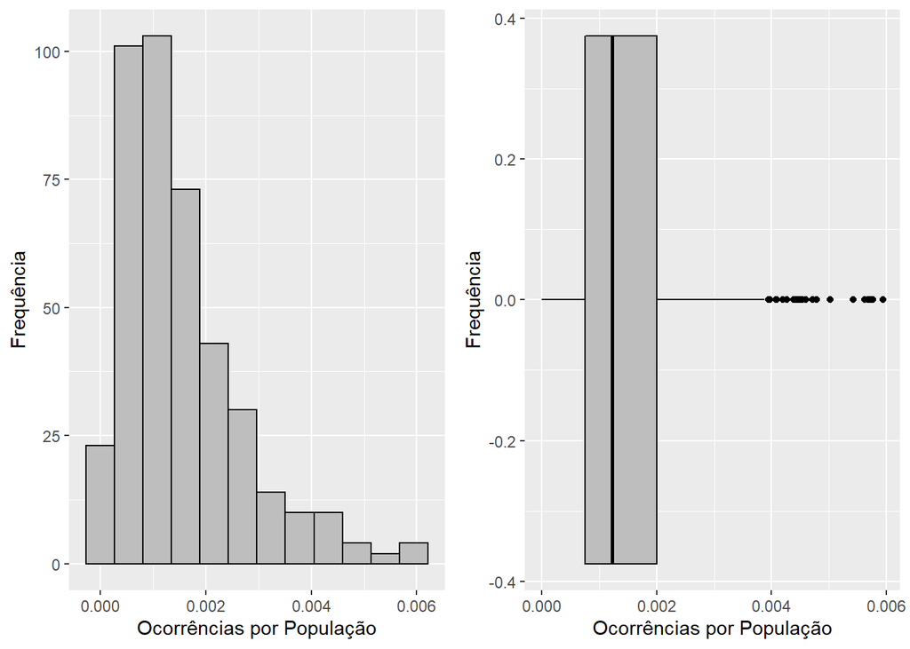

# 4 Correlações entre as variáveis

Com o objetivo de responder à primeira pergunta, sobre o grau de correlação entre os índices de criminalidade e os IDHM, IVS e GINI, os gráficos de dispersão abaixo nos dão uma ideia dessa correlação.

## 4.1 Correlação IDHM x Ocorrências Policiais

Este gráfico ilustra a correlação entre o IDHM e as Ocorrências Policiais para as três classes de cidades (Grande porte, Médio Porte e pequeno Porte). O gráfico sugere que entre essas variáveis há uma correlação positiva. Ou seja, quanto maior o IDHM de uma cidade, maior o índice de criminalidade.

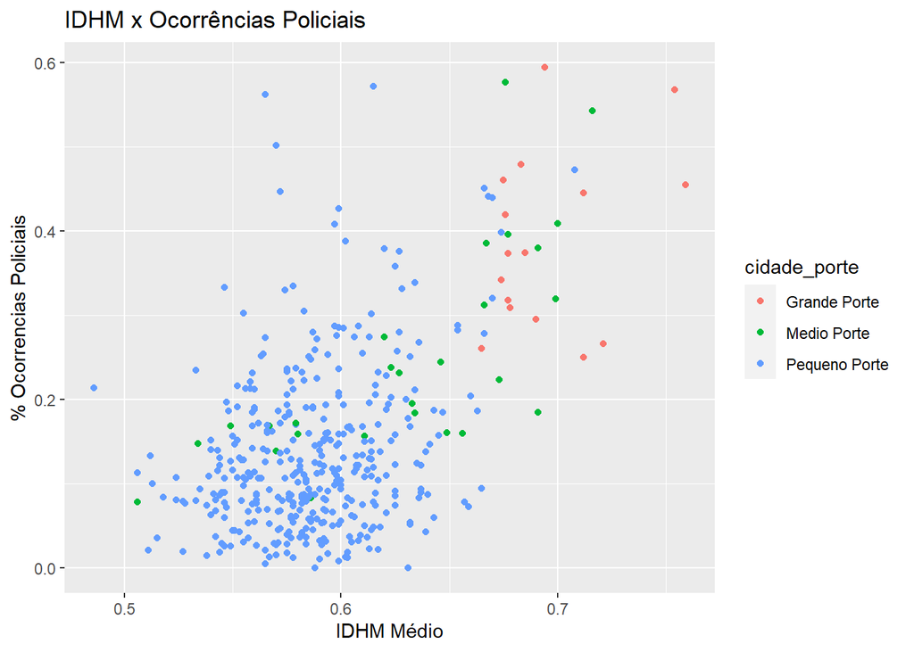

## 4.2 Correlação IVS x Ocorrências Policiais

Seguindo o mesmo raciocínio anterior, o gráfico que correlaciona as variáveis IVS x Ocorrências Policiais aponta para uma correlação negativa entre estas variáveis. Ou seja, quanto maior o IVS de uma cidade, menor o índice de criminalidade.

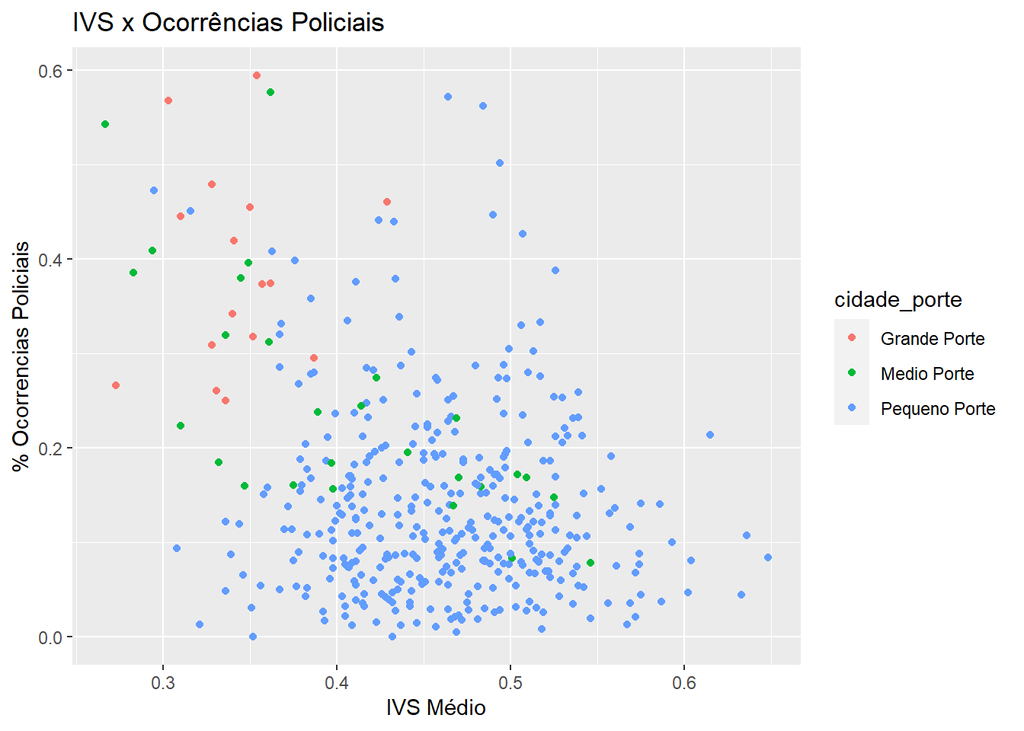

## 4.3 Correlação GINI x Ocorrências Policiais

Diferentemente das correlações anteriores, as variáveis GINI x Ocorrências Policiais parecem não ter uma correlação positiva ou negativa. O que nos sugere que as ocorrências policiais não possuem qualquer relação com o índice de GINI.

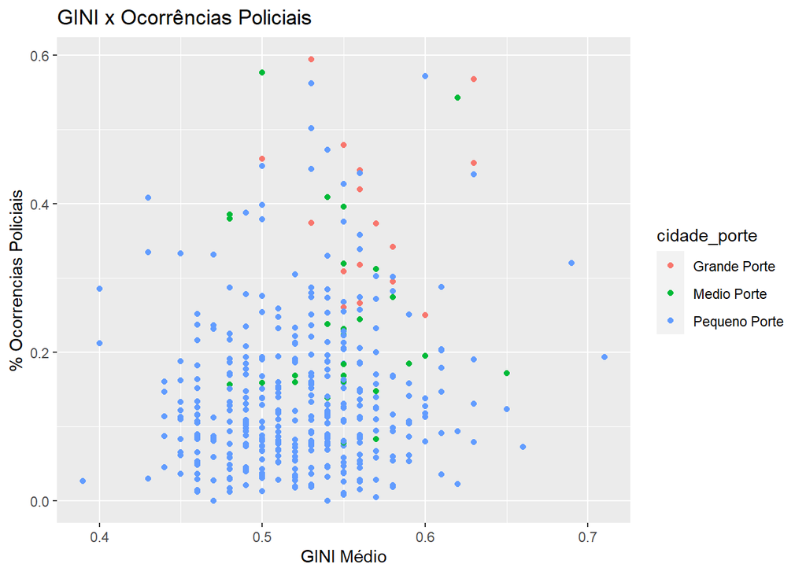

Dessa forma, concluímos que as variáveis IDHM e IVS possuem uma relação direta com o índice de criminalidade. Enquanto que este último índice não parece sofrer influência do índice de GINI.

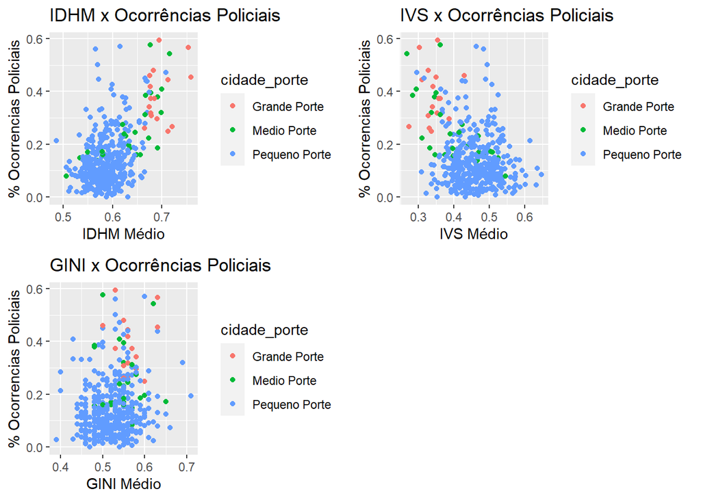

# 5 Teste de Hipótese

Um teste de hipótese se faz necessário quando desejamos validar afirmações referentes a determinada população, através de uma metodologia que nos permita verificar se os dados amostrais trazem evidências que apóiem ou não uma hipótese (estatística) formulada.

Nesse Teste de Hipótese estamos querendo validar a seguinte questão: *Nas cidades de Porte “X”, onde “X” pode ser Pequeno, Médio e Grande, o percentual de ocorrências policiais é maior que a média do Estado ?* Aqui escolhemos as cidades de Pequeno Porte.

O gráfico a seguir verifica se nossos dados seguem uma distribuição Normal.

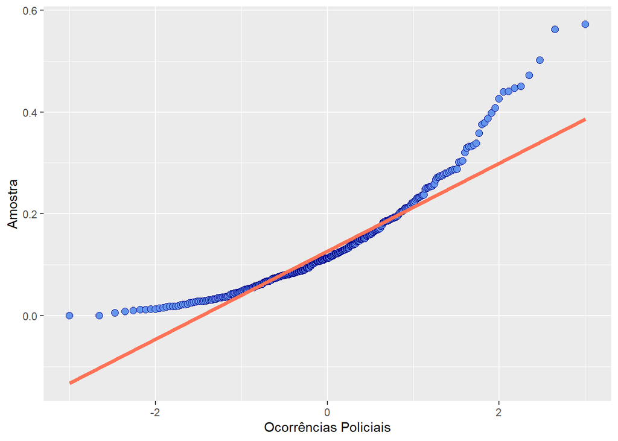

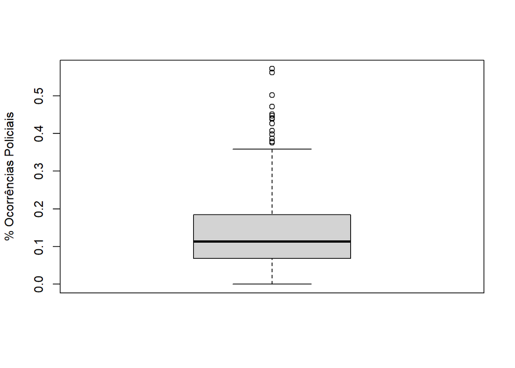

Calculando o p-valor para rejeitar ou não rejeitar 𝐻0

```
##
##  One Sample t-test
##
## data:  df_Cidade_Porte$perc_ocorrencias[df_Cidade_Porte$cidade_porte == "Pequeno Porte"] * 100
## t = -3.3103, df = 373, p-value = 0.9995
## alternative hypothesis: true mean is greater than 15.29
## 95 percent confidence interval:
##  12.76911      Inf
## sample estimates:
## mean of x
##  13.60731
```

Como o p-valor foi 0.9995, nós não rejeitamos 𝐻0.

# 6 Modelo de Regressão Linear

Nessa sessão do relatorio faremos uso de uma análise de regressão para estimar valores do Percentual de Ocorrências Policiais com base nas médias do IDHM e em seguida nas médias do IVS.

Inicialmente geramos um gráfico de dispersão para visualizar a correlação entre as variáveis:

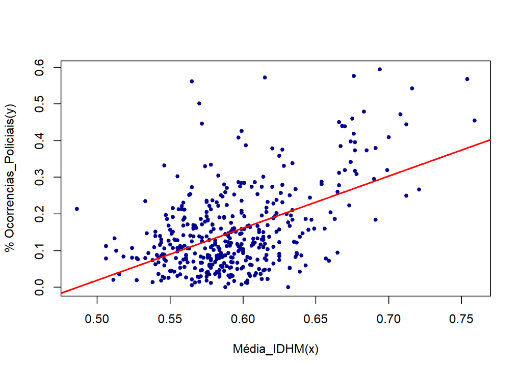

O p-valor calculado é menor que o nivel de significancia (0,5), demonstrando que a variável IDHM Médio é significante na predição do Percentual de Ocorrências Policiais.

```
##
## Call:
## lm(formula = perc_ocorrencias ~ media_idhm, data = df_Cidade_Porte)
##
## Residuals:
##      Min       1Q   Median       3Q      Max
## -0.20561 -0.06775 -0.01343  0.05404  0.44997
##
## Coefficients:
##             Estimate Std. Error t value Pr(>|t|)
## (Intercept) -0.69009    0.06953  -9.925   <2e-16 ***
## media_idhm   1.41949    0.11680  12.153   <2e-16 ***
## ---
## Signif. codes:  0 '***' 0.001 '**' 0.01 '*' 0.05 '.' 0.1 ' ' 1
##
## Residual standard error: 0.09826 on 415 degrees of freedom
## Multiple R-squared:  0.2625, Adjusted R-squared:  0.2607
## F-statistic: 147.7 on 1 and 415 DF,  p-value: < 2.2e-16
```

Análise da variância a fim de verificar o quanto a reta de regressão explica o modelo de regressão

```
## Analysis of Variance Table
##
## Response: perc_ocorrencias
##             Df Sum Sq Mean Sq F value    Pr(>F)
## media_idhm   1 1.4263 1.42626  147.71 < 2.2e-16 ***
## Residuals  415 4.0072 0.00966
## ---
## Signif. codes:  0 '***' 0.001 '**' 0.01 '*' 0.05 '.' 0.1 ' ' 1
```

Os gráficos gerados servem para verificar a adequação do modelo de regressão:

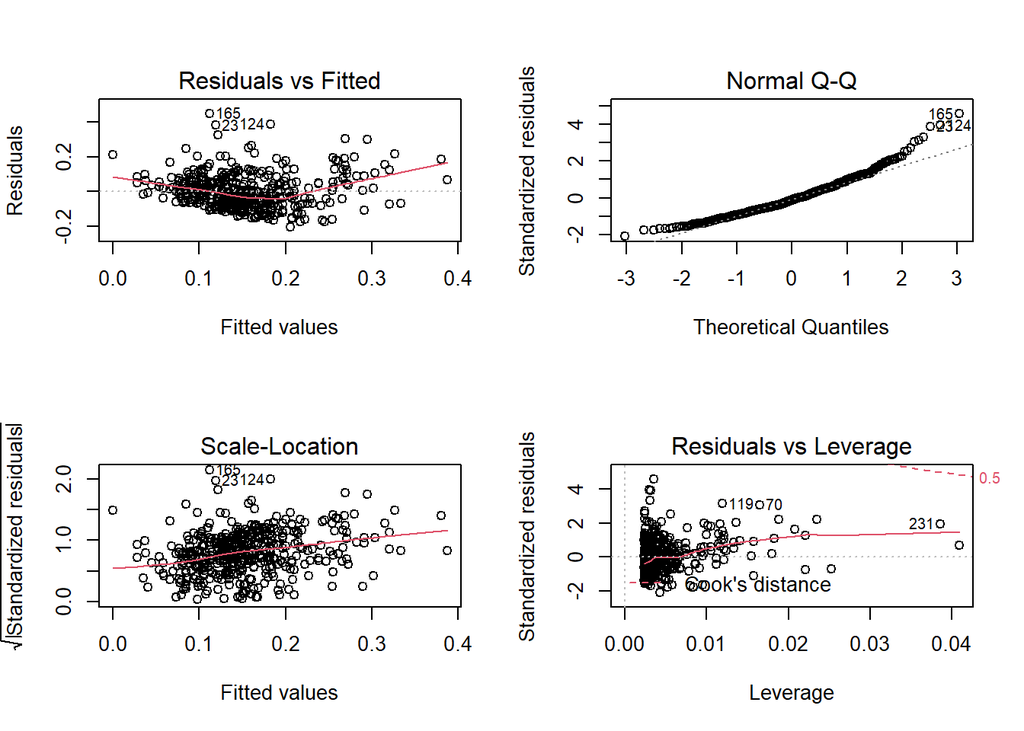

Usamos o teste Shapiro Wilk para verificar a normalidade do modelo:

```
##
##  Shapiro-Wilk normality test
##
## data:  rstandard(modelo)
## W = 0.95262, p-value = 2.616e-10
```

Mais alguns gráficos:

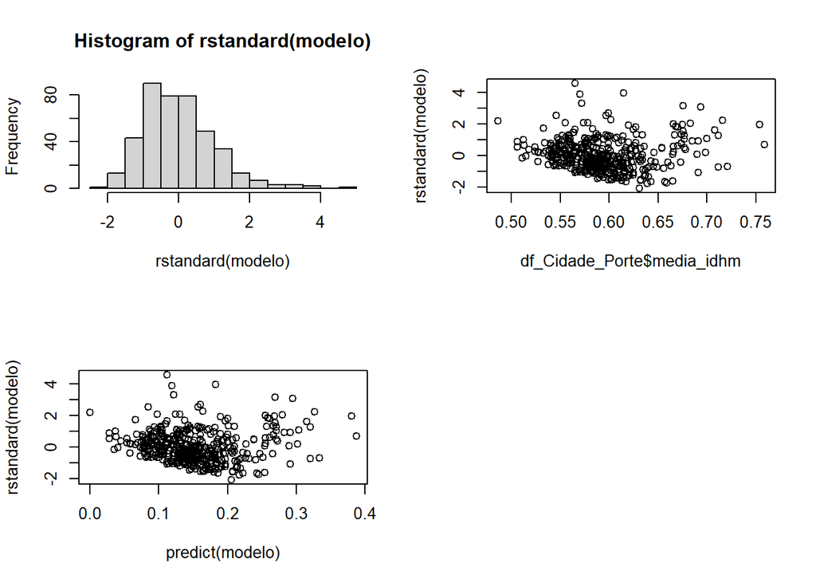

Intervalos de Confiança:

```
##                  2.5 %     97.5 %
## (Intercept) -0.8267733 -0.5534117
## media_idhm   1.1899037  1.6490792
```

```
##         fit        lwr       upr
## 1 0.2751616 0.08076354 0.4695597
```

# 7 Conclusão

A violência no Brasil é um problema sistêmico que vem nos acompanhando desde os tempos de colônia, e em nosso Estado não poderíamos esperar uma realidade distinta. Entretanto, para avaliar e determinar as causas da violência seria necessário a utilização de várias outras variáveis para melhor embasamento e complemento do estudo além das que utilizamos, a exemplo do IDHM e IVS.

É importante destacar que **nenhum** município da Bahia apresenta IDH acima do considerado Médio. Dos 417 municípios apenas 08 estão entre 0.700 e 0.799, sendo 04 da Região Metropolitana de Salvador, 02 do Extremo Oeste, 01 do Centro-Norte e 01 do Sul.

Em relação ao IVS de Infraestrutura, identificamos 12 municípios com variação entre 0.05 e 0.12, dos quais 03 são do Centro-Sul, 02 do Vale São-Franciscano, 02 do Sul, 02 do Nordeste, 01 do Extremo Oeste e 01 da Região Metropolitana de Salvador.

Os municípios com números superiores a 500 ocorrências criminais totalizaram 12, sendo 04 da Região Metropolitana de Salvador, 04 do Sul, 01 do Vale São-Franciscano, 01 do Centro-Norte, 01 do Centro-Sul e 01 do Nordeste.

A relação entre o IDHM e as ocorrências policiais também evidencia uma relação com a população de cada cidade, expondo que as cidades com maior população, são também as cidades com maior Índice de Desenvolvimento Humano e de criminalidade. Dessa forma a Salvador e RMS acabam dominando o ranking da violência no Estado.

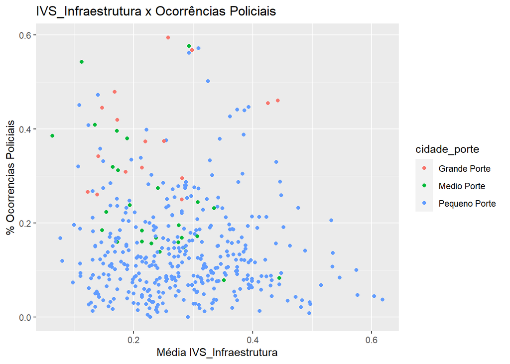

[^1]: [**A Teoria das Janelas Quebradas**](http://www.dpi.policiacivil.pr.gov.br/arquivos/File/ateoriadasjanelaspartiadas.pdf)
[^2]: Alguns pontos sobre as nossas bases de dados carecem de maiores explicações em decorrência do lapso temporal de cada *dataset*. Existe uma não conformidade entre os períodos dos dados da SSP-BA e das demais bases de dados, justificada através da difulcudade de se conseguir informações de ocorrências de Segurança Pública do exercício 2010, para serem contrapostas aos dados dos outros datasets, produzidos no último censo (2010) e que possui dados disponibilizados em fontes abertas.
[^3]: **Crimes Violentos Letais Intencionais (CVLI)** é a designação criada pela Secretaria Nacional de Segurança Pública (SENASP), para a categoria de crimes de homicídio doloso, lesão corporal seguida de morte e roubo com resultado morte, esse último também conhecido como Latrocínio.